# Classification problem using logistic regression, random forest and gbm.

ASLIHAN DEMIRKAYA

## *Introduction*

In this work, our aim is to do classification analysis using logistic regression, random forest, and gbm models on the dataset `creditcard`. We are going to tune the models to improve the results. The dataset we will study can be obtained from https://www.kaggle.com/mlg-ulb/creditcardfraud

### *Exploring the Data Set*

First let’s read the data `creditcard.csv` and explore the data.

```r
#  Do not change the code in this chunk!
creditcard_data <- read.csv('creditcard.csv')
dim(creditcard_data)
```

```
## [1] 284807     31
```

We have 284807 observations and 31 variables.

```r
library(dplyr)
glimpse(creditcard_data )
```

```
## Observations: 284,807
## Variables: 31
## $ Time   <dbl> 0, 0, 1, 1, 2, 2, 4, 7, 7, 9, 10, 10, 10, 11, 12, 12, 1...
## $ V1     <dbl> -1.3598071, 1.1918571, -1.3583541, -0.9662717, -1.15823...
## $ V2     <dbl> -0.07278117, 0.26615071, -1.34016307, -0.18522601, 0.87...
## $ V3     <dbl> 2.53634674, 0.16648011, 1.77320934, 1.79299334, 1.54871...
## $ V4     <dbl> 1.37815522, 0.44815408, 0.37977959, -0.86329128, 0.4030...
## $ V5     <dbl> -0.33832077, 0.06001765, -0.50319813, -0.01030888, -0.4...
## $ V6     <dbl> 0.46238778, -0.08236081, 1.80049938, 1.24720317, 0.0959...
## $ V7     <dbl> 0.239598554, -0.078802983, 0.791460956, 0.237608940, 0....
## $ V8     <dbl> 0.098697901, 0.085101655, 0.247675787, 0.377435875, -0....
## $ V9     <dbl> 0.3637870, -0.2554251, -1.5146543, -1.3870241, 0.817739...
## $ V10    <dbl> 0.09079417, -0.16697441, 0.20764287, -0.05495192, 0.753...
## $ V11    <dbl> -0.55159953, 1.61272666, 0.62450146, -0.22648726, -0.82...
## $ V12    <dbl> -0.61780086, 1.06523531, 0.06608369, 0.17822823, 0.5381...
```

[output cut: 18 more lines]

All the variables are numerical but the variable `Class`. Our aim is to predict the variable `Class`. (takes the value 1 if the transaction is fraud, otherwise 0). The classes are “0” and “1”. Here is the table for the counts.

```r
table(creditcard_data$Class)
```

```
##
##      0      1
## 284315    492
```

As observed, the data is very unbalanced. The size of the data is also big and since our purpose is to understand and apply models, we will work on a smaller size. However, we will keep the full data with `Class=1` to make it less unbalanced.

```r
creditcard_small_class0<-creditcard_data%>%
  filter(Class==0)%>%
  sample_n(size=20000)
```

```r
creditcard_class1<-creditcard_data%>%
  filter(Class==1)
```

Now let’s sum the `creditcard_small` and the data that has `Class=1`.

```r
creditcard_small<-rbind(creditcard_small_class0,creditcard_class1)
```

Now let’s check if we have 20000 obervations with `Class=0` and 492 observations with `Class=1`.

```r
table(creditcard_small$Class)
```

```
##
##     0     1
## 20000   492
```

## *Preparing the dataset*

In order to prevent overfitting, and compare models we split our data set into train-validation and test sets. We also use cross-validation in the models we will present here.

### *Splitting the data into Train-Validation and Test Sets:*

Since we are going to compare models and select the best model at the end of the section, we will split our data into training and testing (80/20). Then we will split the training data into training and validation (again, 80/20).

Below is the R-code that helps us to split our data set into two sets: Training and Testing data.

```r
set.seed(123)
rows <- sample(nrow(creditcard_small)) #randomly order the sampled data
creditcard_small <- creditcard_small[rows, ]
split <- round(nrow(creditcard_small) * .80)
train <- creditcard_small[1:split, ]
test.set <- creditcard_small[(split + 1):nrow(creditcard_small), ]
```

Now, we split our Training Data into two sets: Training and Validation data.

```r
set.seed(123)
rows <- sample(nrow(train)) #randomly order the sampled data
train <- train[rows, ]
split <- round(nrow(train) * .80)
train.set <- train[1:split, ]
validation.set <- train[(split + 1):nrow(train), ]
```

In short, we have three sets now: `train.set` which has 64% of the data, `validation.set` which has 16% of the data and `test.set` which has the 20% of the data.

```r
print(dim(train.set))  #64% of the data set
```

```
## [1] 13115    31
```

```r
print(dim(validation.set)) # 16% of the data set
```

```
## [1] 3279   31
```

```r
print(dim(test.set))  # 20% of the data set
```

```
## [1] 4098   31
```

```r
table(train.set$Class)
```

```
##
##     0     1
## 12798   317
```

```r
table(validation.set$Class)
```

```
##
##    0    1
## 3210   69
```

```r
table(test.set$Class)
```

```
##
##    0    1
## 3992  106
```

### *Using cross-validation method:*

We need `caret` package in order to use cross-validation technique. Here is the R-code we use. We pick number of folders as 5. One can take cv number as 10, too. (Since 5 and 10 are the most used ones.)

```r
library(caret)
myControl <- trainControl(
  method = "cv",
  number = 5,
  summaryFunction = twoClassSummary,
  classProbs = TRUE, # IMPORTANT!
  verboseIter = TRUE
)
```

```r
creditcard_cv<-rbind(train.set,validation.set)
dim(creditcard_cv)
```

```
## [1] 16394    31
```

## *Fitting models using Logistic Regression, Random Forest and GBM models*

Our aim is to write models that will predict the variable `Class`. We will do classifications. We will work on logistic regression, random forest, and gbm models respectively.

### *Fitting models using Logistic Regression*

First, we will start with the basic model: `glm` model for the logistic regression. Following this, we will use `glmnet` since it has hyperparameters we can play.

#### *Using `glm` model:*

In this section, we fit `glm` model to our training data `train.set`. First we change our response variable `Class` to a factor variable. This is necessary for the `glm` model.

```r
train.set$Class<-as.factor(train.set$Class)
```

Our first `glm` model will the basic one, all the variables will be included in the model as follows:

```r
glm_model_1<-glm(Class ~ ., data = train.set, family = binomial(link = "logit"))
summary(glm_model_1)
```

```
##
## Call:
## glm(formula = Class ~ ., family = binomial(link = "logit"), data = train.set)
##
## Deviance Residuals:
##     Min       1Q   Median       3Q      Max
## -7.0953  -0.0736  -0.0445  -0.0282   3.9472
##
## Coefficients:
##               Estimate Std. Error z value Pr(>|z|)
## (Intercept) -6.599e+00  4.726e-01 -13.963  < 2e-16 ***
## Time        -2.702e-06  4.050e-06  -0.667 0.504669
## V1           1.496e-01  9.234e-02   1.620 0.105194
## V2          -5.781e-02  1.797e-01  -0.322 0.747706
## V3          -3.204e-02  1.091e-01  -0.294 0.769093
## V4           8.586e-01  1.281e-01   6.702 2.06e-11 ***
## V5           8.091e-02  1.610e-01   0.503 0.615231
## V6          -2.863e-01  1.531e-01  -1.870 0.061455 .
## V7           2.514e-03  1.817e-01   0.014 0.988964
## V8          -3.602e-01  7.883e-02  -4.569 4.90e-06 ***
## V9          -2.709e-01  1.938e-01  -1.398 0.162237
## V10         -5.181e-01  1.888e-01  -2.744 0.006076 **
## V11          1.196e-01  1.447e-01   0.826 0.408637
## V12         -5.491e-01  1.439e-01  -3.817 0.000135 ***
## V13         -3.308e-01  1.323e-01  -2.500 0.012414 *
## V14         -8.306e-01  1.189e-01  -6.985 2.85e-12 ***
## V15         -2.434e-01  1.524e-01  -1.597 0.110319
## V16         -1.663e-01  2.233e-01  -0.745 0.456423
## V17         -6.988e-02  1.256e-01  -0.556 0.578025
## V18         -1.047e-01  2.332e-01  -0.449 0.653478
## V19          2.983e-01  1.860e-01   1.604 0.108685
## V20         -2.763e-01  2.508e-01  -1.102 0.270563
## V21          3.164e-01  1.170e-01   2.705 0.006836 **
## V22          4.712e-01  2.334e-01   2.019 0.043482 *
## V23         -2.510e-01  1.781e-01  -1.409 0.158899
## V24          1.252e-01  2.661e-01   0.470 0.638034
## V25          1.506e-01  2.602e-01   0.579 0.562813
## V26         -5.157e-01  3.540e-01  -1.457 0.145159
## V27         -3.732e-01  3.287e-01  -1.135 0.256221
## V28          1.035e-01  3.371e-01   0.307 0.758795
## Amount       1.247e-04  1.678e-03   0.074 0.940755
## ---
## Signif. codes:  0 '***' 0.001 '**' 0.01 '*' 0.05 '.' 0.1 ' ' 1
##
## (Dispersion parameter for binomial family taken to be 1)
##
##     Null deviance: 2986.4  on 13114  degrees of freedom
## Residual deviance:  562.3  on 13084  degrees of freedom
## AIC: 624.3
##
## Number of Fisher Scoring iterations: 11
```

```r
glm.probs.1 <- predict(glm_model_1, newdata=validation.set, type="response")  #probability scale
glm.pred.1 <- ifelse(glm.probs.1 > 0.5, 1, 0)
Class_validation <- validation.set$Class
caret::confusionMatrix(as.factor(glm.pred.1),as.factor(Class_validation))
```

```
## Confusion Matrix and Statistics
##
##           Reference
## Prediction    0    1
##          0 3209    9
##          1    1   60
##
##                Accuracy : 0.997
##                  95% CI : (0.9944, 0.9985)
##     No Information Rate : 0.979
##     P-Value [Acc > NIR] : < 2e-16
##
##                   Kappa : 0.9215
##  Mcnemar's Test P-Value : 0.02686
##
##             Sensitivity : 0.9997
##             Specificity : 0.8696
##          Pos Pred Value : 0.9972
##          Neg Pred Value : 0.9836
##              Prevalence : 0.9790
##          Detection Rate : 0.9787
##    Detection Prevalence : 0.9814
##       Balanced Accuracy : 0.9346
##
##        'Positive' Class : 0
##
```

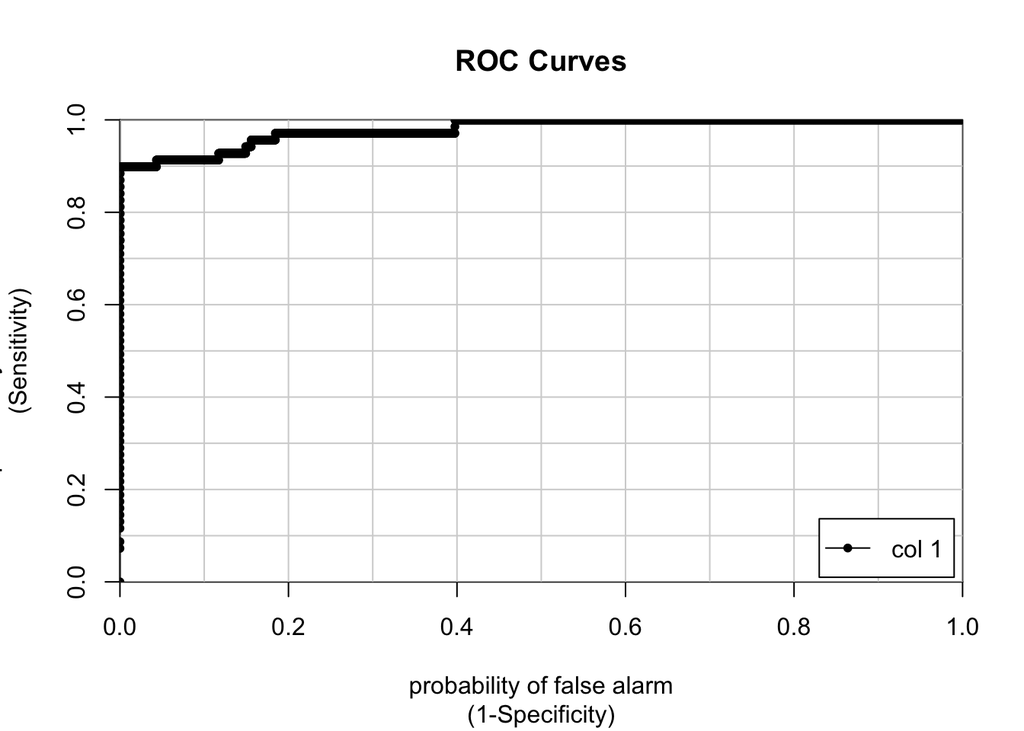

```
##              [,1]
## 0 vs. 1 0.9790103
```

```r
caTools::colAUC(glm.probs.1,  validation.set$Class, plotROC = TRUE)
```

#### *Using `glm` model and Cross-Validation:*

Now, intead of dividing our data set into train and validation set, let’s work on a glm model using cross-validation. We did define myControl in section: Preparing the Data. We will use my Control as `trControl`.

```r
creditcard_cv$Class<-as.factor(creditcard_cv$Class)
levels(creditcard_cv$Class) <- c("negative", "positive")
set.seed(1)
glm_model_cv <- train(Class ~.,creditcard_cv, method = "glm",
  trControl = myControl)
glm_model_cv
```

```
## Generalized Linear Model
##
## 16394 samples
##    30 predictor
##     2 classes: 'negative', 'positive'
##
## No pre-processing
## Resampling: Cross-Validated (5 fold)
## Summary of sample sizes: 13114, 13115, 13116, 13115, 13116
## Resampling results:
##
##   ROC        Sens       Spec
##   0.9778282  0.9997502  0.8393606
```

#### *Using `glmnet` Model:*

```r
library(glmnet)
set.seed(1)
model_glmnet <- train(
Class ~ ., creditcard_cv,
metric = "ROC",
method = "glmnet",
tuneGrid = expand.grid(
alpha = 0:4/4,
lambda = 0:10/10
),
trControl = myControl
)
```

```r
 # Plot the results
model_glmnet
```

```
## glmnet
##
## 16394 samples
##    30 predictor
##     2 classes: 'negative', 'positive'
##
## No pre-processing
## Resampling: Cross-Validated (5 fold)
## Summary of sample sizes: 13114, 13115, 13116, 13115, 13116
## Resampling results across tuning parameters:
##
##   alpha  lambda  ROC        Sens       Spec
##   0.00   0.0     0.9836720  0.9998126  0.78491508
##   0.00   0.1     0.9836458  0.9998751  0.52584083
##   0.00   0.2     0.9828436  0.9998751  0.41438561
##   0.00   0.3     0.9821125  0.9998751  0.33146853
##   0.00   0.4     0.9813398  0.9998751  0.29260739
##   0.00   0.5     0.9806689  0.9998751  0.25624376
##   0.00   0.6     0.9800035  0.9998751  0.20705961
##   0.00   0.7     0.9793731  0.9998751  0.20705961
##   0.00   0.8     0.9788068  0.9998751  0.20705961
##   0.00   0.9     0.9782248  0.9998751  0.20705961
##   0.00   1.0     0.9777190  0.9999375  0.19407259
##   0.25   0.0     0.9784246  0.9997502  0.83936064
##   0.25   0.1     0.9713812  0.9999375  0.33409923
##   0.25   0.2     0.9583664  0.9999375  0.11135531
##   0.25   0.3     0.9570897  1.0000000  0.00000000
##   0.25   0.4     0.9495735  1.0000000  0.00000000
##   0.25   0.5     0.5000000  1.0000000  0.00000000
##   0.25   0.6     0.5000000  1.0000000  0.00000000
##   0.25   0.7     0.5000000  1.0000000  0.00000000
##   0.25   0.8     0.5000000  1.0000000  0.00000000
##   0.25   0.9     0.5000000  1.0000000  0.00000000
##   0.25   1.0     0.5000000  1.0000000  0.00000000
##   0.50   0.0     0.9782445  0.9997502  0.83936064
##   0.50   0.1     0.9580686  0.9999375  0.13986014
##   0.50   0.2     0.9495735  1.0000000  0.00000000
##   0.50   0.3     0.5000000  1.0000000  0.00000000
##   0.50   0.4     0.5000000  1.0000000  0.00000000
##   0.50   0.5     0.5000000  1.0000000  0.00000000
```

[output cut: 15 more lines]

```
##   0.75   1.0     0.5000000  1.0000000  0.00000000
##   1.00   0.0     0.9782786  0.9997502  0.83936064
##   1.00   0.1     0.9495735  1.0000000  0.00000000
##   1.00   0.2     0.5000000  1.0000000  0.00000000
##   1.00   0.3     0.5000000  1.0000000  0.00000000
##   1.00   0.4     0.5000000  1.0000000  0.00000000
##   1.00   0.5     0.5000000  1.0000000  0.00000000
##   1.00   0.6     0.5000000  1.0000000  0.00000000
##   1.00   0.7     0.5000000  1.0000000  0.00000000
##   1.00   0.8     0.5000000  1.0000000  0.00000000
##   1.00   0.9     0.5000000  1.0000000  0.00000000
##   1.00   1.0     0.5000000  1.0000000  0.00000000
##
## ROC was used to select the optimal model using the largest value.
## The final values used for the model were alpha = 0 and lambda = 0.
```

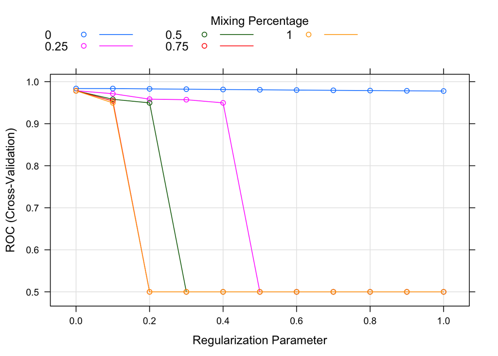

```r
plot(model_glmnet)
```

As seen in the ROC vs Regulalarization Parameter plot above, we see that max ROC occurs at `alpha`=0 and `lambda`=0. With this values, we write `model_glmnet_optimal` as below:

```r
set.seed(1)
model_glmnet_optimal <- train(
Class ~ ., creditcard_cv,
metric = "ROC",
method = "glmnet",
tuneGrid = expand.grid(
alpha = 0,
lambda = 0
),
trControl = myControl
)
model_glmnet_optimal
```

```
## glmnet
##
## 16394 samples
##    30 predictor
##     2 classes: 'negative', 'positive'
##
## No pre-processing
## Resampling: Cross-Validated (5 fold)
## Summary of sample sizes: 13114, 13115, 13116, 13115, 13116
## Resampling results:
##
##   ROC       Sens       Spec
##   0.983672  0.9998126  0.7849151
##
## Tuning parameter 'alpha' was held constant at a value of 0
##
## Tuning parameter 'lambda' was held constant at a value of 0
```

#### *Using Random Forest Model:*

We are going to use `ranger` as a random forest model.

```r
set.seed(1)
model_rf <- train(
Class ~ ., creditcard_cv,
metric = "ROC",
method = "ranger",
trControl = myControl
)
```

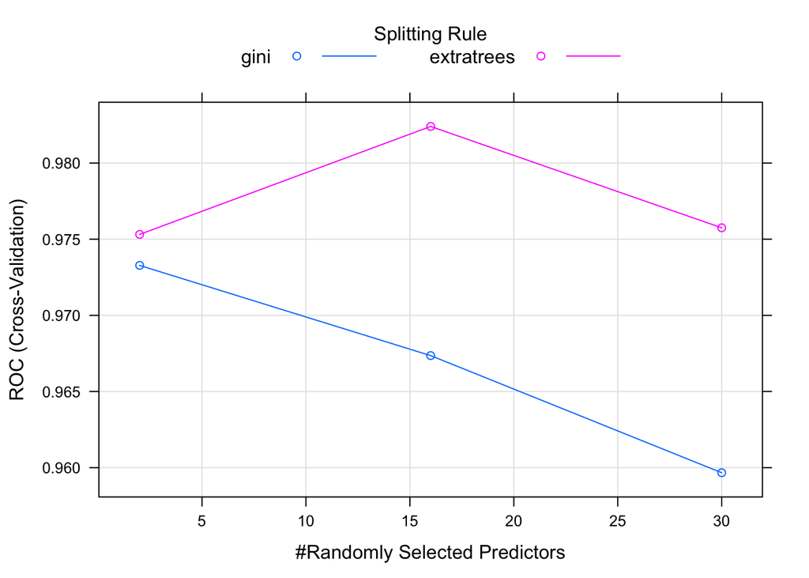

```r
plot(model_rf)
```

```r
model_rf
```

```
## Random Forest
##
## 16394 samples
##    30 predictor
##     2 classes: 'negative', 'positive'
##
## No pre-processing
## Resampling: Cross-Validated (5 fold)
## Summary of sample sizes: 13114, 13115, 13116, 13115, 13116
## Resampling results across tuning parameters:
##
##   mtry  splitrule   ROC        Sens       Spec
##    2    gini        0.9732807  0.9998126  0.8367632
##    2    extratrees  0.9753146  0.9998126  0.8081918
##   16    gini        0.9673565  0.9995627  0.8445554
##   16    extratrees  0.9824031  0.9996877  0.8419580
##   30    gini        0.9596666  0.9995003  0.8419913
##   30    extratrees  0.9757488  0.9996252  0.8445554
##
## Tuning parameter 'min.node.size' was held constant at a value of 1
## ROC was used to select the optimal model using the largest value.
## The final values used for the model were mtry = 16, splitrule =
##  extratrees and min.node.size = 1.
```

#### *Tuning the Random Forest Model:*

In the `ranger` method, the default value for the tuneLength is 3. That’s why we got three mtry values (`mtry`=2,`mtry`=16 and `mtry`=30) for the model `model_rf`. Below we will pick our `tuneLength` as 6 hoping to improve the results.

```r
library(mlbench)
set.seed(1)
model_rf_tuned <- train(
Class ~ ., creditcard_cv,
metric = "ROC",
method = "ranger",
trControl = myControl,
tuneLength = 6
)
```

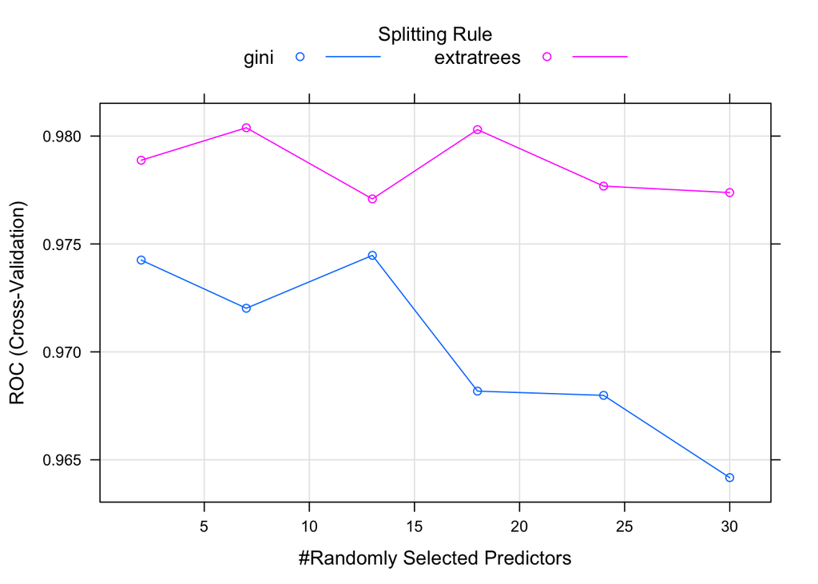

```r
plot(model_rf_tuned)
```

```r
model_rf_tuned
```

```
## Random Forest
##
## 16394 samples
##    30 predictor
##     2 classes: 'negative', 'positive'
##
## No pre-processing
## Resampling: Cross-Validated (5 fold)
## Summary of sample sizes: 13114, 13115, 13116, 13115, 13116
## Resampling results across tuning parameters:
##
##   mtry  splitrule   ROC        Sens       Spec
##    2    gini        0.9742534  0.9998126  0.8367632
##    2    extratrees  0.9788792  0.9998126  0.8081918
##    7    gini        0.9720216  0.9996252  0.8445554
##    7    extratrees  0.9803845  0.9998126  0.8367632
##   13    gini        0.9744719  0.9995627  0.8445554
##   13    extratrees  0.9770874  0.9997501  0.8393606
##   18    gini        0.9681816  0.9995003  0.8445554
##   18    extratrees  0.9802982  0.9996252  0.8419580
##   24    gini        0.9679850  0.9995627  0.8419913
##   24    extratrees  0.9776809  0.9996252  0.8445554
##   30    gini        0.9641731  0.9995003  0.8419913
##   30    extratrees  0.9773813  0.9996252  0.8419580
##
## Tuning parameter 'min.node.size' was held constant at a value of 1
## ROC was used to select the optimal model using the largest value.
## The final values used for the model were mtry = 7, splitrule =
##  extratrees and min.node.size = 1.
```